# AQS 88101 ‘Known Locations’

Jonathan Callahan

September 27, 2021

# Introduction

The USFS [AirFire](https://www.airfire.org) group is focused on air quality associated with wildfire smoke and maintains both historical and real-time databases of air quality monitoring data obtained from stationary monitors (*i.e.* not *“mobile monitors”*). This data is used in operational displays and for retrospective analysis. Data ingest and management of air quality “stationary time series” is thus an important ongoing activity.

Challenges include: * Location stability – jitter in reported longitude and latitude coming from GPS. * Data duplication – data from an individual monitor arriving through separate data streams. * CPU-intense spatial searches for data such as time zone.

To address these and other issues, we are creating a “known locations” table – a set of which locations which have been vetted for reuse by AirFire and for which all CPU-intensive spatial queries have already been performed.

Isolating purely spatial information from monitor-related information will allow us to quickly assign incoming data to a “known location” and immediately retrieve associated spatial data that would otherwise require expensive spatial calculations.

The basic concept for creating a *“known locations”* table is described in the introduction to the [MazamaLocationUtils](https://mazamascience.github.io/MazamaLocationUtils/) R package.

Because the focus is on wildifres, the spatial scale of interest is >= 500 meters and each “known location” will be understood to represent a circle with a radius of 250 meters. Any incoming data records whose longitude and latitude fall within 250m of an existing location will assigned to that “known location”. New “known locations” will be added as needed.

# Setup

```r
library(MazamaCoreUtils)

library(AirMonitorIngest)

# Create a directory specifically for EPA data
dir.create("~/Data/EPA", showWarnings = FALSE, recursive = TRUE)
```

We will begin with an existing database of EPA AQS site information. This database is assumed to be largely well vetted and contain most of the relevant spatial information we will need for further data processing and visualization.

## Download Data

### AQS sites

The `AQS_sites` table contains primarily spatial location information with additional *“site”* information that is specific to an individual monitor, *e.g.* `Owning Agency`. As we will see, it is possible to have multiple *“sites”* at a single *“known location”*.

```r
# Get site metadata
AQS_sites <- epa_aqs_getSites(downloadDir = "~/Data/EPA")

dim(AQS_sites)
names(AQS_sites)
```

```
## [1] 20730    28
##  [1] "State Code"            "County Code"           "Site Number"
##  [4] "Latitude"              "Longitude"             "Datum"
##  [7] "Elevation"             "Land Use"              "Location Setting"
## [10] "Site Established Date" "Site Closed Date"      "Met Site State Code"
## [13] "Met Site County Code"  "Met Site Site Number"  "Met Site Type"
## [16] "Met Site Distance"     "Met Site Direction"    "GMT Offset"
## [19] "Owning Agency"         "Local Site Name"       "Address"
## [22] "Zip Code"              "State Name"            "County Name"
## [25] "City Name"             "CBSA Name"             "Tribe Name"
## [28] "Extraction Date"
```

### AQS Monitors

The `AQS_monitors` table mixes monitor-specific information like `Parameter Code` and `Last Sample Data` with location-specific information like `State Code` or `CBSA Name`.

```r
# Get monitor metadata
AQS_monitors <- epa_aqs_getMonitors(downloadDir = "~/Data/EPA")

dim(AQS_monitors)
names(AQS_monitors)
```

```
## [1] 356777     32
##  [1] "State Code"                   "County Code"
##  [3] "Site Number"                  "Parameter Code"
##  [5] "Parameter Name"               "POC"
##  [7] "Latitude"                     "Longitude"
##  [9] "Datum"                        "First Year of Data"
## [11] "Last Sample Date"             "Monitor Type"
## [13] "Networks"                     "Reporting Agency"
## [15] "PQAO"                         "Collecting Agency"
## [17] "Exclusions"                   "Monitoring Objective"
## [19] "Last Method Code"             "Last Method"
## [21] "Measurement Scale"            "Measurement Scale Definition"
## [23] "NAAQS Primary Monitor"        "QA Primary Monitor"
## [25] "Local Site Name"              "Address"
## [27] "State Name"                   "County Name"
## [29] "City Name"                    "CBSA Name"
## [31] "Tribe Name"                   "Extraction Date"
```

### AQS Parameter Codes

The `AQS_parameterCodes` table provides detailed information on each individual parameter (pollutant) found in the AQS data.

```r
# Get parameter codes
AQS_parameterCodes <- epa_aqs_getCodes(tableName = "parameters")

dim(AQS_parameterCodes)
names(AQS_parameterCodes)
```

```
## [1] 1477    8
## [1] "Parameter Code"           "Parameter"
## [3] "Parameter Abbreviation"   "Parameter Alternate Name"
## [5] "CAS Number"               "Standard Units"
## [7] "Still Valid"              "Round or Truncate"
```

## Explore `AQS_monitors`

### Parameter Codes

The two most important parameter codes for AirFire PM2.5 measurements are `"88101"` and `"88502"`.

#### 88101

```r
AQS_parameterCodes %>%
  dplyr::filter(`Parameter Code` %in% c("88101")) %>%
  dplyr::glimpse()
```

```
## Rows: 1
## Columns: 8
## $ `Parameter Code`           <chr> "88101"
## $ Parameter                  <chr> "PM2.5 - Local Conditions"
## $ `Parameter Abbreviation`   <chr> "LC25"
## $ `Parameter Alternate Name` <chr> NA
## $ `CAS Number`               <chr> NA
## $ `Standard Units`           <chr> "Micrograms/cubic meter (LC)"
## $ `Still Valid`              <chr> "YES"
## $ `Round or Truncate`        <chr> "T"
```

#### 88502

```r
AQS_parameterCodes %>%
  dplyr::filter(`Parameter Code` %in% c("88502")) %>%
  dplyr::glimpse()
```

```
## Rows: 1
## Columns: 8
## $ `Parameter Code`           <chr> "88502"
## $ Parameter                  <chr> "Acceptable PM2.5 AQI & Speciation Mass"
## $ `Parameter Abbreviation`   <chr> "PM2.5"
## $ `Parameter Alternate Name` <chr> NA
## $ `CAS Number`               <chr> NA
## $ `Standard Units`           <chr> "Micrograms/cubic meter (LC)"
## $ `Still Valid`              <chr> "YES"
## $ `Round or Truncate`        <chr> "T"
```

### Measurement Scale

As seen in the output below, `Measurement Scale` provides important information on the appropriate use of data from a particular monitor. The AirFire *“known locations”* table will be used in the context of wildfire smoke over large regions. For this use case, we will ignore measurement scales < 500m.

```r
AQS_monitors %>%
  dplyr::mutate(scale_definition = paste(`Measurement Scale`, `Measurement Scale Definition`, sep = ' -- ')) %>%
  dplyr::pull(`scale_definition`) %>%
  unique() %>% sort()
```

```
## [1] "MICROSCALE -- 0 M TO 100 M"          "MIDDLE SCALE -- 100 M TO 500 M"
## [3] "NA -- NA"                            "NEIGHBORHOOD -- 500 M TO 4KM"
## [5] "REGIONAL SCALE -- 50 TO HUNDREDS KM" "URBAN SCALE -- 4 KM TO 50 KM"
```

## Subset for Sites with Parameter Code 88101

### Subset Monitors

We begin by subsetting `AQS_monitors` to include only those monitors used in regulatory decision making – PM2.5 FRM/FEM or `88101` and only those associated with `POC ==` – the first monitor deployed at an AQS *site*. We will use state, county and site information to create an `AQSID` which is typically associated with a monitor-site. The `AQSID can be created for both`AQS_monitors`and`AQS_sites`, allowing us to create queries combining the two.

```r
AQS_monitors_0 <-
  AQS_monitors %>%
  # Subset
  dplyr::filter(`Measurement Scale` != "MICROSCALE") %>%
  dplyr::filter(`Measurement Scale` != "MIDDLE SCALE") %>%
  dplyr::filter(`Parameter Code` == "88101") %>%
  dplyr::filter(`POC` == "1") %>%
  # Add AQSID as a unique identifier
  dplyr::mutate(
    AQSID = paste0(`State Code`, `County Code`, `Site Number`)
  )

dim(AQS_monitors_0)
```

```
## [1] 1592   33
```

### Subset Sites

```r
AQS_sites_0 <-
  AQS_sites %>%
  # Add AQSID as a unique identifier
  dplyr::mutate(
    AQSID = paste0(`State Code`, `County Code`, `Site Number`)
  ) %>%
  # Subset
  dplyr::filter(AQSID %in% AQS_monitors_0$AQSID)

dim(AQS_sites_0)
```

```
## [1] 1592   29
```

## Create a “Known Locations” Table

We will build a standardized *“known locations”* table using the *MazamaLocationUtils*. This will involve:

- creating standardized variables
- adding spatial metadata

We begin by initializing *MazamaLocationUtils* and associated datasets and then display the column names we need to create.

```r
library(MazamaSpatialUtils)
library(MazamaLocationUtils)

# Set up spatial data
MazamaLocationUtils::mazama_initialize("~/Data/Spatial")

# Print out names for an empty "known locations" table
known_location_columns <-
  MazamaLocationUtils::table_initialize() %>%
  names()
```

### Create Standard Variables

The recipe below performs this in stages primarily using functions from *dplyr*.

```r
known_locations_0 <-

  # Start with AQS_sites_0
  AQS_sites_0 %>%

  # Rename all existing columns with "AQS_"
  dplyr::rename_all(make.names) %>%
  dplyr::rename_all(~ gsub("^", "AQS_", .x)) %>%

  # Add "known location" columns derived from AQS columns where possible
  dplyr::mutate(
    locationID = as.character(NA),
    locationName = AQS_Local.Site.Name,
    longitude = AQS_Longitude,
    latitude = AQS_Latitude,
    elevation = AQS_Elevation,
    countryCode = as.character(NA),
    stateCode = MazamaSpatialUtils::US_stateFIPSToCode(AQS_State.Code),
    county = AQS_County.Name,
    timezone = as.character(NA),
    houseNumber = as.character(NA),
    street = as.character(NA),
    city = AQS_City.Name,
    zip = AQS_Zip.Code
  )
```

For convenience of use with `View()`, we will reorganize the columns with “known location” columns first and get a sense of our data by creating a map of all locations:

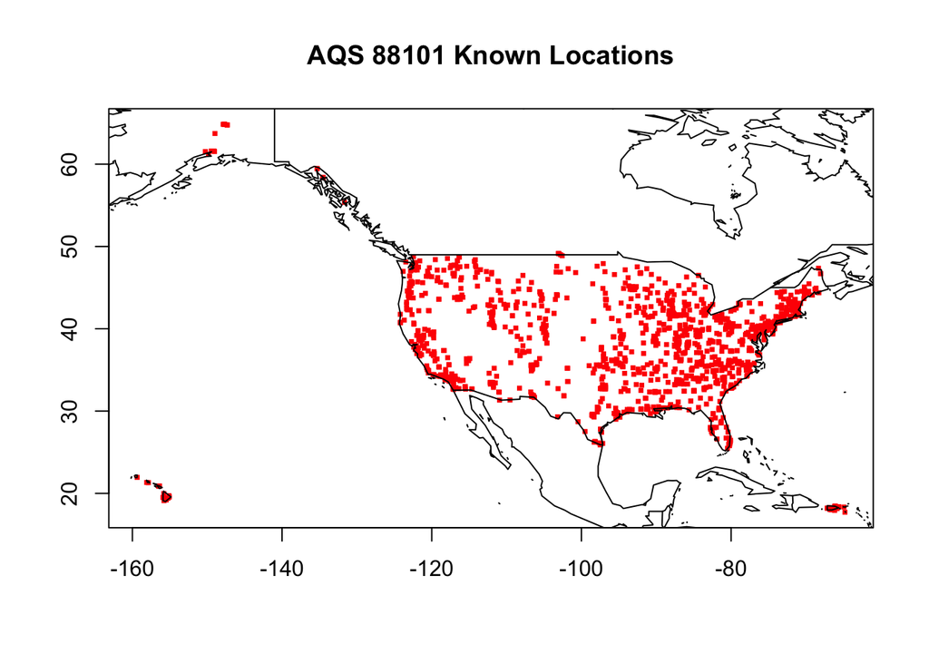

```r
# Get "AQS_" columns
AQS_columns <-
  names(known_locations_0) %>%
  stringr::str_subset("AQS_.*")

# Reorder column names
known_locations_0 <-
  known_locations_0 %>%
  dplyr::select(dplyr::all_of(c(known_location_columns, AQS_columns)))

plot(
  known_locations_0$longitude, known_locations_0$latitude,
  pch = 15, cex = 0.5, col  = "red",
  xlab = "", ylab = "",
  main = "AQS 88101 Known Locations"
)

maps::map("world", add = TRUE)
```

### Add/fix Required Columns

Several columns of data were set to `NA` when we created `known_locations_0`. These columns require a bit more work and are dealt with here:

```r
# Add ISO countryCodes
known_locations_0$countryCode <-
  dplyr::case_when(
    known_locations_0$AQS_State.Code == "66" ~ "GU",
    known_locations_0$AQS_State.Code == "72" ~ "PR",
    known_locations_0$AQS_State.Code == "78" ~ "VI",
    known_locations_0$AQS_State.Code == "80" ~ "MX",
    known_locations_0$AQS_State.Code == "CC" ~ "CA",
    TRUE ~ "US" # default
  )

# Add unique identifiers
known_locations_0$locationID <-
  MazamaLocationUtils::location_createID(
    known_locations_0$longitude,
    known_locations_0$latitude
  )

# Add timezones
known_locations_0$timezone <-
  MazamaSpatialUtils::getTimezone(
    known_locations_0$longitude,
    known_locations_0$latitude,
    # NOTE:  EPA has monitors from US, Canada, Mexico, Puerto Rico, Virgin Islands and Guam
    countryCodes = c("US", "CA", "MX", "PR", "VI", "GU"),
    useBuffering = TRUE
)

# TODO:  Fix stateCode where countryCode != "US"
```

### Review

It’s now time to review our first pass table, `known_locations_0`:

```r
# What country codes to we have?
table(known_locations_0$countryCode)
```

```
##
##   CA   PR   US   VI
##    2   15 1573    2
```

```r
# Are all locations unique?
any(duplicated(known_locations_0$locationID))
```

```
## [1] FALSE
```

### Impose 500 Meter Separation

As described in the Introduction, we want the AirFire “known locations” table to have a measurement scale >= 500 meters. We will use functions from *MazamaLocationUtils* to identify overlapping locations and deal with them on an individual basis.

### Find Overlapping Locations

```r
distance_table <-
  dplyr::select(known_locations_0, longitude, latitude) %>%
  MazamaLocationUtils::table_findAdjacentDistances(distanceThreshold = 500)

print(distance_table)
```

```
## # A tibble: 37 × 3
##     row1  row2 distance
##    <int> <int>    <dbl>
##  1   389   390     32.5
##  2  1255  1256     39.6
##  3   854   855     46.0
##  4   889   890     53.1
##  5   901   904     55.5
##  6   790   791     68.9
##  7   774   781     73.9
##  8    36    40     74.8
##  9  1019  1021     80.4
## 10  1065  1067     88.1
## # … with 27 more rows
```

So we have 74 separate *“sites”* involved in 37 overlaps given our chosen 500m separation rule. Further investigation is in order.

### Leaflet Inspection

We can use the `leaflet_table()` function to examine overlapping *“sites”* and make executive decisions based on other metadata as to which one we will use for our *“known location”* representing that area.

```r
source("table_leaflet.R")
# Which sites are too close
known_locations_0 %>%
  MazamaLocationUtils::table_findAdjacentLocations(distanceThreshold = 500) %>%
  table_leaflet()
```

[interactive chart not shown]

### Manual Editing

We will work our way through all “too close” sites and decide which locations should be elided from our location table. We hide the details but show the results:

```r
print(IDs_for_removal)
```

```
##  [1] "020900029" "530330004" "160170004" "160270005" "410250002" "410390058"
##  [7] "410330114" "060190008" "060730003" "060250003" "461030019" "311570004"
## [13] "080010001" "080070002" "350439003" "350019004" "484390063" "120992003"
## [19] "720570008" "450450008" "290470041" "291893001" "171132002" "171610003"
## [25] "550790058" "390950025" "391130014" "390490024" "390490025" "391550005"
## [31] "390810016" "390811001" "540390009" "240330001" "340030007" "340172002"
## [37] "360810124"
```

## Final “Known Locations” Table

### Subset

Removing these monitors will leave us with a table where every monitor is at least 500 meters away from their nearest neighbor.

```r
dim(known_locations_0)
```

```
## [1] 1592   42
```

```r
known_locations <-
  known_locations_0 %>%
  dplyr::filter(!AQS_AQSID %in% IDs_for_removal)

dim(known_locations)
```

```
## [1] 1555   42
```

### Consistent Casing

```r
known_locations$locationName <-
  stringr::str_to_title(known_locations$locationName)
```

### Non-US State Codes

Using ISO standards requires that we re-evaluate states codes for non-US countries.

```r
# Split, fix and then recombine
US <- dplyr::filter(known_locations, countryCode == "US")
non_US <- dplyr::filter(known_locations, countryCode != "US")

non_US$stateCode <-
  MazamaSpatialUtils::getStateCode(
    non_US$longitude,
    non_US$latitude,
    dataset = "NaturalEarthAdm1",
    countryCodes = c("CA", "MX", "VI", "GU"),
    useBuffering = TRUE
  )

# Combine two tables
known_locations <-
  dplyr::bind_rows(
    US,
    non_US
  )
```

### Minor improvements

```r
known_locations <-
  known_locations %>%
  dplyr::mutate(city = dplyr::na_if(city, "Not in a City")) %>%
  dplyr::mutate(city = dplyr::na_if(city, "Not in a city"))
```

# Final Result

```r
table_leaflet(known_locations)
```

[interactive chart not shown]

## Compare with removed locations

```r
removed_locations <-
  known_locations_0 %>%
  dplyr::filter(AQS_AQSID %in% IDs_for_removal)

map <- table_leaflet(known_locations)

table_leafletAdd(map, removed_locations)
```

[interactive chart not shown]

```r
setLocationDataDir("~/Data/Known_Locations")
table_save(known_locations, "AirFire_monitors_500m")

table_csv <- table_export(known_locations)
readr::write_csv(known_locations, file = file.path(getLocationDataDir(), "AirFire_monitors_500m.csv"))
```